# M11-2-Application-R_Programing.qmd

Author

William Jackson

Published

May 15, 2025

# Question 1

> Create a vector “quantity” and assign 50 to it. If the quantity is greater than 20, your code should print “You sold a lot”; otherwise, print “Not enough for today.”

```r
# Create a vector named "quantity"
quantity <- 50

# Check if quantity is greater than 20
if (quantity > 20) {
  print("You sold a lot")
} else {
  print("Not enough for today.")
}
```

```
[1] "You sold a lot"
```

# Question 2

> Create a vector “sales” and assign the value 25 to it. If the value is less than 20, your code should print “Not enough for today.” If the quantity sold is between 20 and 30 inclusively, print “Average Day.” If your sales amount is greater than 30, print out “You had a great day!”

```r
# Create a vector named "sales"
sales <- 25

# Conditional checks
if (sales < 20) {
  print("Not enough for today.")
} else if (sales >= 20 && sales <= 30) {
  print("Average Day.")
} else {
  print("You had a great day!")
}
```

```
[1] "Average Day."
```

# Question 3

> Each product has its own category and also the respective tax rate applied to it. Therefore, products in category “A” are taxed by 8%, category “B” by 10%, and category “C” by 20%. Create a vector, “category,” and assign a value “A” to the vector. Also, create a vector “price” and assign it 100. Create an if statement that identifies the categories and applies the tax rate to the price of this product. In the end, print the tax rate applied and the final price. For example, for a product in the “B” category (price=10), your printout must be: “A tax rate of 10% is applied. The total price is 11.”

```r
# Create vectors
category <- "A"
price <- 100

# Apply tax rate based on category
if (category == "A") {
  tax_rate <- 0.08
} else if (category == "B") {
  tax_rate <- 0.10
} else if (category == "C") {
  tax_rate <- 0.20
} else {
  tax_rate <- 0
}

# Calculate total price
total_price <- price * (1 + tax_rate)

# Print the results
print(paste0("A tax rate of ", tax_rate * 100, "% is applied. The total price is ", total_price, "."))
```

```
[1] "A tax rate of 8% is applied. The total price is 108."
```

# Question 4

> Create a for loop to count the even numbers in a vector q4. This vector must contain the values 2, 5, 3, 9, 8, 11, and 6. Your output must be 3.

```r
# Create the vector q4
q4 <- c(2, 5, 3, 9, 8, 11, 6)

# Initialize counter
even_count <- 0

# For loop to count even numbers
for (num in q4) {
  if (num %% 2 == 0) {
    even_count <- even_count + 1
  }
}

# Print the number of even numbers
print(even_count)
```

```
[1] 3
```

# Question 5

> Create a vector q5 in the range of 1 to 8. For each one of the numbers in the vector, if it is greater than 4 and even, print it. Otherwise, print “Condition not satisfied”. Your output must have 8 lines, showing the numbers 6 and 8 in two of the eight lines.

```r
# Create the vector q5
q5 <- 1:8

# For loop to check conditions
for (num in q5) {
  if (num > 4 && num %% 2 == 0) {
    print(num)
  } else {
    print("Condition not satisfied")
  }
}
```

```
[1] "Condition not satisfied"
[1] "Condition not satisfied"
[1] "Condition not satisfied"
[1] "Condition not satisfied"
[1] "Condition not satisfied"
[1] 6
[1] "Condition not satisfied"
[1] 8
```

# Question 6

> Create a function called “pow” that takes two arguments: x and y. The first argument is raised to the power of the second one, and prints the result like this: “8 raised to the power of 2 is 64.” Lastly, call the function with those values after creating the function.

```r
# Create the function "pow"
pow <- function(x, y) {
  result <- x^y
  print(paste0(x, " raised to the power of ", y, " is ", result, "."))
}

# Call the function with x = 8 and y = 2
pow(8, 2)
```

```
[1] "8 raised to the power of 2 is 64."
```

# Question 7

> Q7.1. Run this line of code: df <- data.frame(x = 1:4, y = 5:8, z = 10:13). Use the apply function to get the mean and sum of each ROW on this dataframe. Add them to the data frame.

```r
# Create the dataframe
df <- data.frame(x = 1:4, y = 5:8, z = 10:13)

# Calculate row means and sums using apply()
row_means <- apply(df, 1, mean)
row_sums <- apply(df, 1, sum)

# Add the results to the original dataframe
df$mean <- row_means
df$sum <- row_sums

# Print the updated dataframe
print(df)
```

```
  x y  z     mean sum
1 1 5 10 5.333333  16
2 2 6 11 6.333333  19
3 3 7 12 7.333333  22
4 4 8 13 8.333333  25
```

> Q7.2. Create a vector called q8 and assign the values 12, 18, and 6. Next, use the apply family and map family functions to calculate the square root of each element.

```r
# Create the vector q8
q8 <- c(12, 18, 6)

# Using sapply (apply family) to calculate the square root
sqrt_sapply <- sapply(q8, sqrt)
print(sqrt_sapply)
```

```
[1] 3.464102 4.242641 2.449490
```

```r
# Using purrr::map (map family) to calculate the square root
library(purrr)
sqrt_map <- map_dbl(q8, sqrt)  # map_dbl because we want numeric output
print(sqrt_map)
```

```
[1] 3.464102 4.242641 2.449490
```

> Q7.3. Run this code below: q9 <- list(A = 1:5, B = 6:20, C = 1). Use the apply family and map family functions to calculate the number of components of each element of this list. *Hint*: Use the length function.

```r
# Create the list q9
q9 <- list(A = 1:5, B = 6:20, C = 1)

# Using sapply (apply family) to calculate the length of each element in the list
length_sapply <- sapply(q9, length)
print(length_sapply)
```

```
 A  B  C
 5 15  1
```

```r
# Using purrr::map (map family) to calculate the length of each element
library(purrr)
length_map <- map_int(q9, length)  # map_int because we want integer output
print(length_map)
```

```
 A  B  C
 5 15  1
```

> Q7.4. What is the difference between lapply and sapply functions. Which map functions are similar to them? Consider that you want to calculate the exponentials of three numbers. In this case, which function you should use and why? Type your answer as a comment?

```r
# Difference between lapply and sapply:

# lapply() returns a list regardless of the output structure, even if the results can be simplified.
# sapply() attempts to simplify the output (for example, into a vector, matrix, or array) whenever possible.

# Map equivalents:
# - lapply() is similar to map() (both return a list).
# - sapply() is similar to map_lgl(), map_int(), map_dbl(), or map_chr(), depending on the desired output type.

# To calculate exponentials of three numbers:
numbers <- c(2, 3, 4)

# Using lapply() (returns a list)
exp_lapply <- lapply(numbers, exp)
print(exp_lapply)
```

```
[[1]]
[1] 7.389056

[[2]]
[1] 20.08554

[[3]]
[1] 54.59815
```

```r
# Using sapply() (returns a vector)
exp_sapply <- sapply(numbers, exp)
print(exp_sapply)
```

```
[1]  7.389056 20.085537 54.598150
```

```r
# The best function to use depends on the desired output:
# If you want a list of the results, use lapply().
# If you want a simplified output like a numeric vector, use sapply().

# In this case, I would recommend using sapply() because the result is numeric and simplified (vector),
# which is more appropriate when you're calculating exponentials for a set of numbers and need a vector of results.
```

# Question 8

> Q8.1: First, execute the following codes in the code chunk to read the data into R and set the global theme.

```r
library(tidyverse)

theme_set(theme_bw())

student_ratio <- read_csv("https://raw.githubusercontent.com/rfordatascience/tidytuesday/master/data/2019/2019-05-07/student_teacher_ratio.csv")
```

> Q8.2. Explore the data. Especially count the number of “year”, the “indicator”, and “country”, separately.

```r
# Count the number of unique years
year_count <- student_ratio %>%
  count(year)

# Count the number of unique indicators
indicator_count <- student_ratio %>%
  count(indicator)

# Count the number of unique countries
country_count <- student_ratio %>%
  count(country)

# Display the counts
year_count
```

| year | n |
| --- | --- |
| 2012 | 887 |
| 2013 | 880 |
| 2014 | 913 |
| 2015 | 921 |
| 2016 | 917 |
| 2017 | 635 |
| 2018 | 36 |

```r
indicator_count
```

| indicator | n |
| --- | --- |
| Lower Secondary Education | 739 |
| Post-Secondary Non-Tertiary Education | 494 |
| Pre-Primary Education | 837 |
| Primary Education | 1029 |
| Secondary Education | 840 |
| Tertiary Education | 550 |
| Upper Secondary Education | 700 |

```r
country_count
```

| country | n |
| --- | --- |
| Afghanistan | 13 |
| Africa (Northern) | 30 |
| Africa (Sub-Saharan) | 28 |
| Albania | 36 |
| Algeria | 18 |
| Andorra | 29 |
| Angola | 7 |
| Antigua and Barbuda | 13 |
| Arab States | 30 |
| Argentina | 5 |

[output cut: 222 more lines]

> Q8.3. Next, draw a chart that shows the top and bottom 10 countries in student-teacher ratio for 2012.

```r
# Inspect column names to confirm the correct column name for the ratio
colnames(student_ratio)
```

```
[1] "edulit_ind"    "indicator"     "country_code"  "country"
[5] "year"          "student_ratio" "flag_codes"    "flags"
```

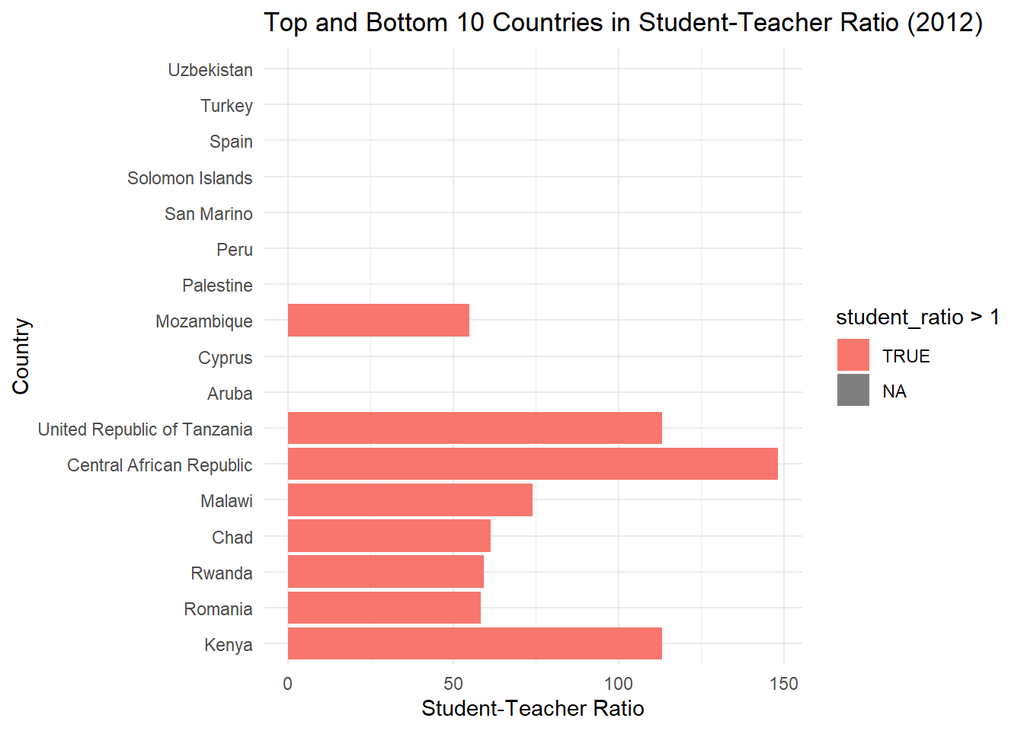

```r
# Filter the data for the year 2012
data_2012 <- student_ratio %>%
  filter(year == 2012) %>%
  arrange(desc(student_ratio))  # Sort by the student-teacher ratio

# Get the top and bottom 10 countries
top_bottom_10 <- bind_rows(
  head(data_2012, 10),  # Top 10 countries
  tail(data_2012, 10)   # Bottom 10 countries
)

# Create a bar chart to visualize the top and bottom 10 countries
ggplot(top_bottom_10, aes(x = reorder(country, student_ratio), y = student_ratio, fill = student_ratio > 1)) +
  geom_bar(stat = "identity") +
  coord_flip() +  # Flip the coordinates for better readability
  labs(
    title = "Top and Bottom 10 Countries in Student-Teacher Ratio (2012)",
    x = "Country",
    y = "Student-Teacher Ratio"
  ) +
  theme_minimal()
```

> Q8.4. Note that there are six years from 2012 to 2017 that have a significant number of observations, conducive for drawing charts by year. Since you don’t want to copy and paste the code again and again, you want to create a function that allows you to use it to draw all the charts by simply entering “year” information into the function. You will want to show “year” information in the chart as a subtitle. Create such a function.

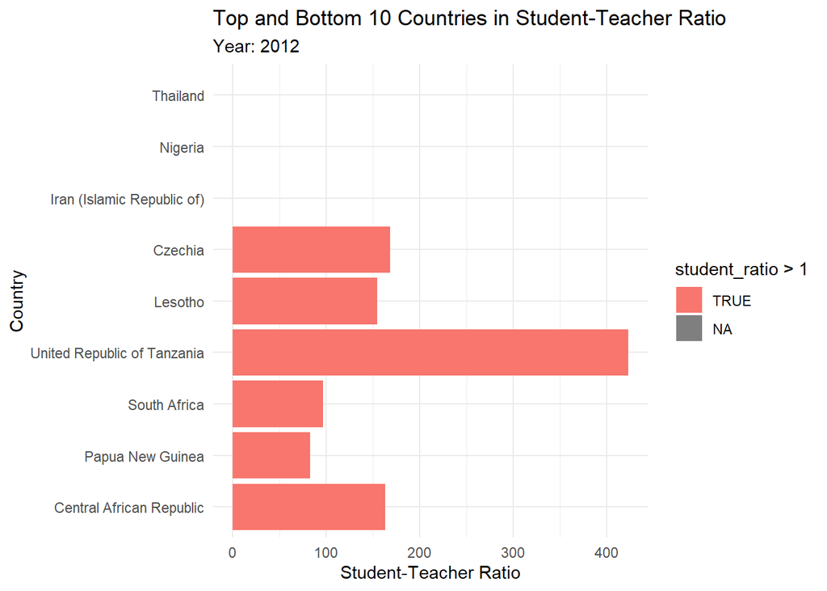

```r
# Define the function to create a chart for a given year
create_student_teacher_chart <- function(year) {
  # Filter the data for the specified year
  data_year <- student_ratio %>%
    filter(year == year) %>%
    arrange(desc(student_ratio))  # Sort by the student-teacher ratio

  # Get the top and bottom 10 countries
  top_bottom_10 <- bind_rows(
    head(data_year, 10),  # Top 10 countries
    tail(data_year, 10)   # Bottom 10 countries
  )

  # Create the bar chart
  ggplot(top_bottom_10, aes(x = reorder(country, student_ratio), y = student_ratio, fill = student_ratio > 1)) +
    geom_bar(stat = "identity") +
    coord_flip() +  # Flip the coordinates for better readability
    labs(
      title = paste("Top and Bottom 10 Countries in Student-Teacher Ratio"),
      subtitle = paste("Year:", year),  # Add the year as a subtitle
      x = "Country",
      y = "Student-Teacher Ratio"
    ) +
    theme_minimal()
}

# Example usage: Call the function for the year 2012
create_student_teacher_chart(2012)
```

```r
library(ggplot2)
library(dplyr)
library(tidyr)

# Remove rows with missing student_ratio values
student_ratio_clean <- na.omit(student_ratio)

# Check the structure of the cleaned data
summary(student_ratio_clean)
```

```
  edulit_ind         indicator         country_code         country
 Length:679         Length:679         Length:679         Length:679
 Class :character   Class :character   Class :character   Class :character
 Mode  :character   Mode  :character   Mode  :character   Mode  :character



      year      student_ratio      flag_codes           flags
 Min.   :2012   Min.   :  2.418   Length:679         Length:679
 1st Qu.:2013   1st Qu.: 14.332   Class :character   Class :character
 Median :2014   Median : 18.785   Mode  :character   Mode  :character
 Mean   :2015   Mean   : 20.998
 3rd Qu.:2016   3rd Qu.: 23.800
 Max.   :2017   Max.   :155.000
```

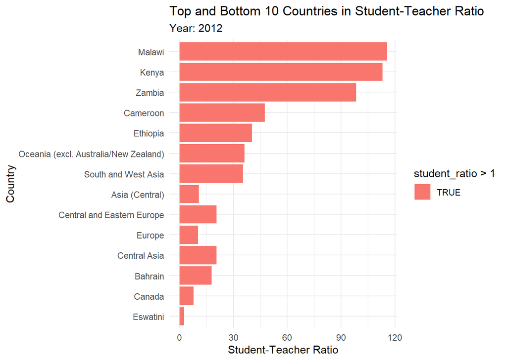

```r
# Filter the data for 2012
data_2012 <- student_ratio_clean %>%
  filter(year == 2012) %>%
  arrange(desc(student_ratio))

# Get the top and bottom 10 countries
top_bottom_10 <- bind_rows(
  head(data_2012, 10),  # Top 10 countries
  tail(data_2012, 10)   # Bottom 10 countries
)

# Create a bar chart for 2012
ggplot(top_bottom_10, aes(x = reorder(country, student_ratio), y = student_ratio, fill = student_ratio > 1)) +
  geom_bar(stat = "identity") +
  coord_flip() +
  labs(
    title = "Top and Bottom 10 Countries in Student-Teacher Ratio",
    subtitle = "Year: 2012",
    x = "Country",
    y = "Student-Teacher Ratio"
  ) +
  theme_minimal()
```

# Question 9

> Q9.0. Read the following data in R and be prepared for analysis.

```r
animal_outcomes <- readr::read_csv('https://raw.githubusercontent.com/rfordatascience/tidytuesday/master/data/2020/2020-07-21/animal_outcomes.csv')
animal_complaints <- readr::read_csv('https://raw.githubusercontent.com/rfordatascience/tidytuesday/master/data/2020/2020-07-21/animal_complaints.csv')
brisbane_complaints <- readr::read_csv('https://raw.githubusercontent.com/rfordatascience/tidytuesday/master/data/2020/2020-07-21/brisbane_complaints.csv')
```

> Q9.1. First, briefly take a look at each data set. You will notice that some variables are lower case while others are upper case. You will also notice that some variables are consist of more than one word.

```r
# View the structure of each dataset to check variables and data types
str(animal_outcomes)
```

```
spc_tbl_ [664 × 12] (S3: spec_tbl_df/tbl_df/tbl/data.frame)
 $ year       : num [1:664] 1999 1999 1999 1999 1999 ...
 $ animal_type: chr [1:664] "Dogs" "Dogs" "Dogs" "Dogs" ...
 $ outcome    : chr [1:664] "Reclaimed" "Rehomed" "Other" "Euthanized" ...
 $ ACT        : num [1:664] 610 1245 12 360 111 ...
 $ NSW        : num [1:664] 3140 7525 745 9221 201 ...
 $ NT         : num [1:664] 205 526 955 9 22 269 0 847 1 3 ...
 $ QLD        : num [1:664] 1392 5489 860 9214 206 ...
 $ SA         : num [1:664] 2329 1105 380 1701 157 ...
 $ TAS        : num [1:664] 516 480 168 599 31 ...
 $ VIC        : num [1:664] 7130 4908 1001 5217 884 ...
 $ WA         : num [1:664] 1 137 6 18 0 62 5 5 0 0 ...
 $ Total      : num [1:664] 15323 21415 4127 26339 1612 ...
 - attr(*, "spec")=
  .. cols(
  ..   year = col_double(),
  ..   animal_type = col_character(),
  ..   outcome = col_character(),
  ..   ACT = col_double(),
  ..   NSW = col_double(),
  ..   NT = col_double(),
  ..   QLD = col_double(),
  ..   SA = col_double(),
  ..   TAS = col_double(),
  ..   VIC = col_double(),
  ..   WA = col_double(),
  ..   Total = col_double()
  .. )
 - attr(*, "problems")=<externalptr>
```

```r
str(animal_complaints)
```

```
spc_tbl_ [42,413 × 5] (S3: spec_tbl_df/tbl_df/tbl/data.frame)
 $ Animal Type       : chr [1:42413] "dog" "dog" "dog" "dog" ...
 $ Complaint Type    : chr [1:42413] "Aggressive Animal" "Noise" "Noise" "Private Impound" ...
 $ Date Received     : chr [1:42413] "June 2020" "June 2020" "June 2020" "June 2020" ...
 $ Suburb            : chr [1:42413] "Alice River" "Alice River" "Alice River" "Alice River" ...
 $ Electoral Division: chr [1:42413] "Division 1" "Division 1" "Division 1" "Division 1" ...
 - attr(*, "spec")=
  .. cols(
  ..   `Animal Type` = col_character(),
  ..   `Complaint Type` = col_character(),
  ..   `Date Received` = col_character(),
  ..   Suburb = col_character(),
  ..   `Electoral Division` = col_character()
  .. )
 - attr(*, "problems")=<externalptr>
```

```r
str(brisbane_complaints)
```

```
spc_tbl_ [31,330 × 7] (S3: spec_tbl_df/tbl_df/tbl/data.frame)
 $ nature            : chr [1:31330] "Animal" "Animal" "Animal" "Animal" ...
 $ animal_type       : chr [1:31330] "Dog" "Dog" "Dog" "Dog" ...
 $ category          : chr [1:31330] "Fencing Issues" "Fencing Issues" "Defecating In Public" "Fencing Issues" ...
 $ suburb            : chr [1:31330] "SUNNYBANK" "SUNNYBANK HILLS" "SUNNYBANK" "SUNNYBANK" ...
 $ date_range        : chr [1:31330] "1st-quarter-2016-17.csv" "1st-quarter-2016-17.csv" "1st-quarter-2016-17.csv" "1st-quarter-2016-17.csv" ...
 $ responsible_office: chr [1:31330] NA NA NA NA ...
 $ city              : chr [1:31330] "Brisbane" "Brisbane" "Brisbane" "Brisbane" ...
 - attr(*, "spec")=
  .. cols(
  ..   nature = col_character(),
  ..   animal_type = col_character(),
  ..   category = col_character(),
  ..   suburb = col_character(),
  ..   date_range = col_character(),
  ..   responsible_office = col_character(),
  ..   city = col_character()
  .. )
 - attr(*, "problems")=<externalptr>
```

```r
# View the column names of each dataset to check case and multi-word variable names
colnames(animal_outcomes)
```

```
 [1] "year"        "animal_type" "outcome"     "ACT"         "NSW"
 [6] "NT"          "QLD"         "SA"          "TAS"         "VIC"
[11] "WA"          "Total"
```

```r
colnames(animal_complaints)
```

```
[1] "Animal Type"        "Complaint Type"     "Date Received"
[4] "Suburb"             "Electoral Division"
```

```r
colnames(brisbane_complaints)
```

```
[1] "nature"             "animal_type"        "category"
[4] "suburb"             "date_range"         "responsible_office"
[7] "city"
```

> Q9.2. Create a pipeable function that will help you clean up the variable names across the data set, clean them up using the function, and reassign the data sets to the same names to overwrite them.

```r
# Create a function to clean column names
clean_colnames <- function(df) {
  colnames(df) <- tolower(gsub(" ", "_", colnames(df)))
  return(df)
}

# Clean up the column names in each dataset using the function
animal_outcomes <- animal_outcomes %>% clean_colnames()
animal_complaints <- animal_complaints %>% clean_colnames()
brisbane_complaints <- brisbane_complaints %>% clean_colnames()

# View the updated column names for verification
colnames(animal_outcomes)
```

```
 [1] "year"        "animal_type" "outcome"     "act"         "nsw"
 [6] "nt"          "qld"         "sa"          "tas"         "vic"
[11] "wa"          "total"
```

```r
colnames(animal_complaints)
```

```
[1] "animal_type"        "complaint_type"     "date_received"
[4] "suburb"             "electoral_division"
```

```r
colnames(brisbane_complaints)
```

```
[1] "nature"             "animal_type"        "category"
[4] "suburb"             "date_range"         "responsible_office"
[7] "city"
```

> Q9.3. Create a pipeable function that can draw a bar chart showing a count of a variable from any of the three data sets above.

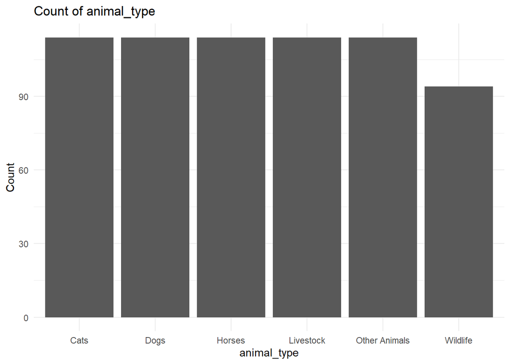

```r
# Create a pipeable function to draw a bar chart for a variable
draw_bar_chart <- function(df, variable) {
  df %>%
    count(!!sym(variable)) %>%  # Count occurrences of each unique value in the variable
    ggplot(aes(x = !!sym(variable), y = n)) +  # Plot the variable on x and count on y
    geom_bar(stat = "identity") +  # Use identity to plot the count
    theme_minimal() +  # Clean theme
    labs(x = variable, y = "Count", title = paste("Count of", variable))  # Labels and title
}

# Example usage:
# Drawing a bar chart for 'animal_type' from the animal_outcomes dataset
draw_bar_chart(animal_outcomes, "animal_type")
```

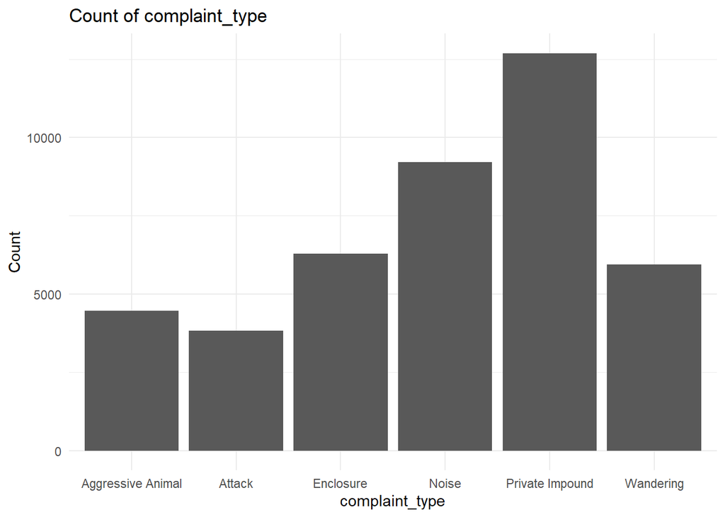

```r
# Drawing a bar chart for 'complaint_type' from the animal_complaints dataset
draw_bar_chart(animal_complaints, "complaint_type")
```

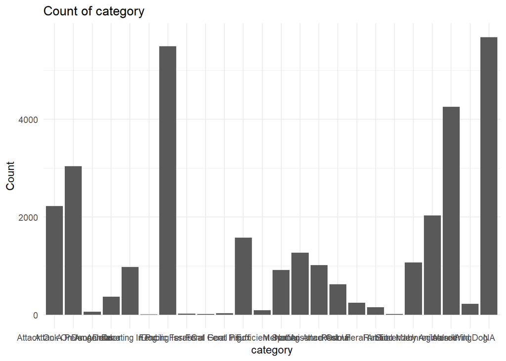

```r
# Drawing a bar chart for 'category' from the brisbane_complaints dataset
draw_bar_chart(brisbane_complaints, "category")
```

> Q9.4. Then, using the function, create two bar charts of your interest from each data set.

```r
# Load the janitor package
library(janitor)

# Clean column names in all datasets
animal_outcomes <- animal_outcomes %>% clean_names()
animal_complaints <- animal_complaints %>% clean_names()
brisbane_complaints <- brisbane_complaints %>% clean_names()

# Verify the column names to ensure they are cleaned properly
colnames(animal_outcomes)
```

```
 [1] "year"        "animal_type" "outcome"     "act"         "nsw"
 [6] "nt"          "qld"         "sa"          "tas"         "vic"
[11] "wa"          "total"
```

```r
colnames(animal_complaints)
```

```
[1] "animal_type"        "complaint_type"     "date_received"
[4] "suburb"             "electoral_division"
```

```r
colnames(brisbane_complaints)
```

```
[1] "nature"             "animal_type"        "category"
[4] "suburb"             "date_range"         "responsible_office"
[7] "city"
```

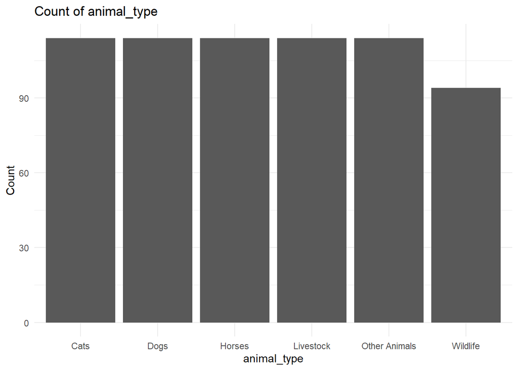

```r
# Drawing two bar charts for animal_outcomes dataset:
# 1. Count of animal types
draw_bar_chart(animal_outcomes, "animal_type")
```

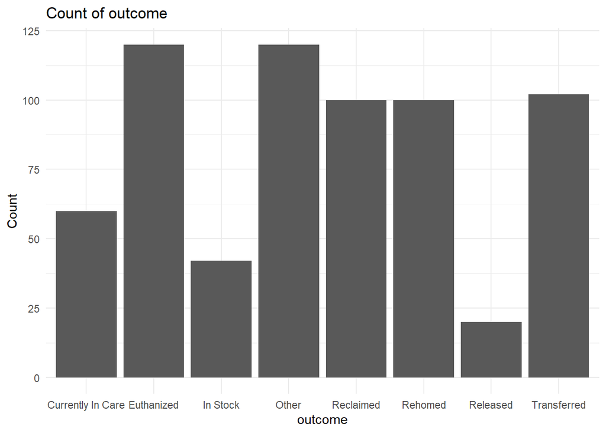

```r
# 2. Count of outcomes
draw_bar_chart(animal_outcomes, "outcome")
```

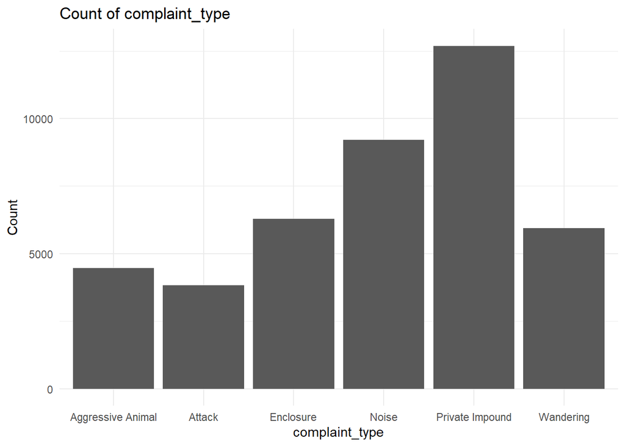

```r
# Drawing two bar charts for animal_complaints dataset:
# 1. Count of complaint types
draw_bar_chart(animal_complaints, "complaint_type")
```

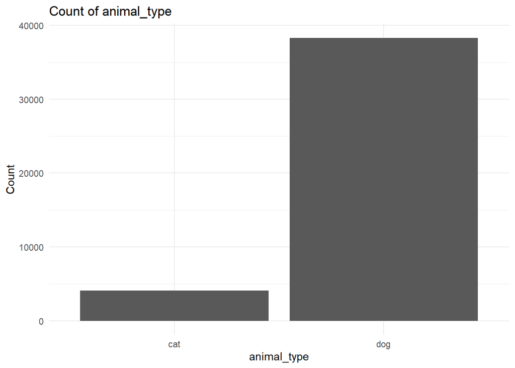

```r
# 2. Count of animal types
draw_bar_chart(animal_complaints, "animal_type")
```

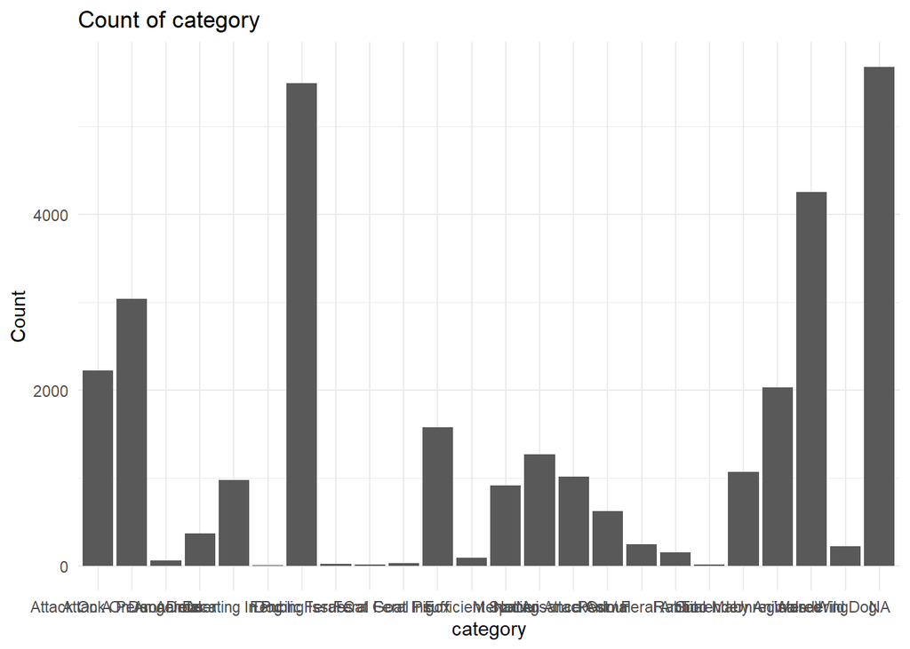

```r
# Drawing two bar charts for brisbane_complaints dataset:
# 1. Count of complaint categories
draw_bar_chart(brisbane_complaints, "category")
```

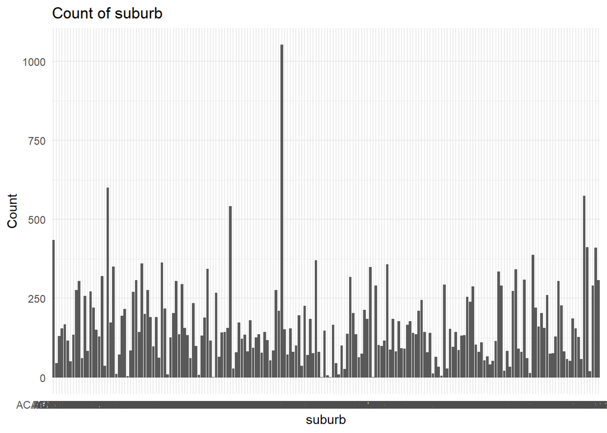

```r
# 2. Count of suburbs
draw_bar_chart(brisbane_complaints, "suburb")
```

# Question 10

> In this question, you will work with “airquality” data set, which is built-in data available from R Studio. The goal is to create a function that calculates average Ozone amount for each month. *Hints*: Use nested data. You will have to create multiple functions with one function embedded in another. Also, use one of the map() functions.

```r
# Load necessary libraries
library(dplyr)
library(purrr)

# Define the function to calculate average Ozone per month
calculate_avg_ozone_per_month <- function(data) {
  # Helper function to calculate average for a specific month
  calc_avg_ozone <- function(month) {
    data %>%
      filter(Month == month) %>%
      summarise(avg_ozone = mean(Ozone, na.rm = TRUE)) %>%
      pull(avg_ozone)
  }

  # Get unique months (the months are represented by 5 to 9 in the airquality dataset)
  months <- unique(data$Month)

  # Use map to apply the helper function to each month
  avg_ozone_by_month <- map_dbl(months, calc_avg_ozone)

  # Return results in a tibble
  tibble(Month = months, Avg_Ozone = avg_ozone_by_month)
}

# Apply the function on the airquality data
average_ozone <- calculate_avg_ozone_per_month(airquality)
print(average_ozone)
```

```
# A tibble: 5 × 2
  Month Avg_Ozone
  <int>     <dbl>
1     5      23.6
2     6      29.4
3     7      59.1
4     8      60.0
5     9      31.4
```